# DivvyBike Analysis

Kelly Zhao, John Kuk

# Executive Summary

The Divvy bike system was strategically placed around the Chicagoland area to be known as the “last mile” transportation service. We are making assumptions that those renting are not actively thinking or aware of crime data at time of rental. Also, that Divvy rental placements decisions were already made where rental potential is high due to this “last mile” need. We decided to go with the Stepwise model after evaluating multiple models. While performing analysis we can say that from our baseline of no model has a gain from 0.8617029 to 0.2237982. While ridge provides better performance, stepwise is more concise with variables. The tradeoff between ridge and stepwise is negligible where MSE is 0.2212045 versus 0.2237982.

**Final Model - Stepwise:**

formula = trips ~ PARK_AREA_ACRES + CTA_TRAIN_STATIONS + Limited_Business_License + CAPACITY + MINORITY + ASSAULT + BATTERY + BURGLARY + THEFT

1. PARK_AREA_ACRES: Negative relationship with trips. Some thoughts are that if the park is small people prefer to bike, if the park is too big, people prefer to drive. Also, bikes at perimeter of parks versus being in them, so purpose and motivation to use bikes is possibly different when a park is involved, and other activities in parks are considered versus renting and riding bikes.
2. CTA_TRAIN_STATIONS: Negative relationship with trips. There is a possibility that if there are too many train stations, people can go to anywhere by train and therefore less need of a bike. Another thought the group had was that train stations have less correlation than buses because it is harder to make or change train stations. Busses are flexible and their routes can be changed; Divvy stations are even more flexible and individual routes can vary dramatically.
3. Limited_Business_License: Positive relationship with trips. This makes sense in that more retailors means there might be more people walking and biking.
4. CAPACITY: Positive relationship with trips. Places where there are more bikes there can be more available for rental.
5. MINORITY: Negative relationship with trips. Is that those that are of a minority have less need for bikes or this kind of service? Thoughts that come up is possibly riding bikes is a lifestyle choice and some may already have bikes of their own so no need to rent one.
6. ASSAULT: Negative relationship with trips. Assault by definition is the threat of harm.
7. BATTERY: Positive relationship with trips. Battery by definition is cause of real physical harm. Thought is that maybe people are more likely to walk or bike in safer area (ASSAULT) so this influences bike rental negatively. Whereas for BATTERY it is likely people will go through these areas quickly to avoid so it will influence bike rental positively. ASSAULT and BATTERY have a quite strong correlation of 0.95, might due to the nature of the 2 kinds of crime are pretty similar. So, the sign of relationship with trips is not quite reliable. Overall, these two kinds of crime have a negative relation with trips, indicating that people might be less likely to ride in dangerous areas, though the evidence is not solid.
8. BURGLARY: Negative relationship with trips. Definition is to enter a building or residence with the intention to commit a theft or any felonious crime. This kind of crime might be more common where people live, instead of where people work or shop, so bike demand could be less.
9. THEFT: Positive relationship with trips. Definition is to take property, and it does not involve person-to-person interaction with force. It is easier to steal when people are walking or shopping than when they are driving or riding a bike.

**Theory:**

The challenge was to develop a theory to explain how different types of crime will affect Divvy bike demand. Generally, we believe that crime in these areas does not directly cause an increase in bike rentals nor do bike rentals directly cause crime. However, we do not have enough information to say this definitively and make this conclusion. For those who use the service there may also be a subset of people who are more comfortable walking or may not be as savvy to use the service. Service users may have budgets, and this is part of their daily normal commute option. For individuals living and traversing crime areas, they may not be aware of the crime or care. Or, they do care, but their needs and their lives have them already coping that this is normal for them and there may not necessarily be driven by fear of crime activity.

As for Divvy locations being near CTA train stations and places where there are businesses, this logically makes sense for those who will use the service for “last mile” traversal. This also explains why park areas have a negative relationship where bike riders are not looking for rentals for joy riding and instead wanting that purposeful destination travel. Divvy may have decided that placement to these locations is ideal, so this already biases the data showing correlation with these locations.

Crime for us seems as something a bike rider would not necessarily be aware of when renting a bike if their need or lifestyle choice to ride bikes frequently determines whether they rent a bike or not. Although the data is correlated it does not mean it makes bike riders rent or not rent if they have different motivations to rent in the first place. The sense is that where there is higher population where these bikes are located there will be more occurrence naturally of these kinds of crimes. There is not anything that tells us that these crimes were specific to bike riders.

**Model Usage and Recommendations:**

- The model could be used for finding the most profitable new spot.
- To further explore the relationship between crime data and trips:
  - Collect data to confirm if Divvy renters are aware of crime in these locations.
  - Confirm if any of this crime affects Divvy renters directly.
  - Collect data related to capacity and if at certain locations bikes are over utilized (running out of bikes).
- Leverage the model and crime data to determine Divvy placement for new locations where higher levels (magnitude) of crime (ASSAULT, BATTERY, BURGLARY, and THEFT) regardless of negative/positive effect to trips is a desirable placement. These places will have more business and will likely have more crime, and as such, provide more favorable conditions for Divvy bike rentals.
- Similarly, leverage the model to adjust placement towards locations where there are higher levels of crime. These locations may be desirable not because of crime itself, but because of other factors due to “last mile” needs. Adjustments can also be made with regards to capacity to be able to rent more bikes.

# The Challenge

- **How does the type and amount of crime around a Divvy bike station affect the demand for bikes, as measured by the number of rentals per time period?** We also want to assess how other independent variables are related to demand.
- I will be providing you with a data set giving the **demand at n = 300 bike stations**, but I want you to think about what results you would expect before looking at the data.
- I do not expect you to read other research articles.
- Instead, I want you to think about **what could happen in the model and explanations for why.**
- Your data will have data on how often 31 different crimes occurred in the area around the bike share station during the previous year.
- I have lagged the crime data to avoid problems with reverse causality.
- **Many of the crimes are rare, so we will focus on the following eight (you could use the other if you want): theft, battery, deceptive practice, assault, burglary, robbery, criminal trespassing, narcotics, and homicide.**
- You might want to google these terms for more precise definitions. For example, my understanding is that assault involves a threat, but not bodily harm, while battery implies harm. Deceptive practice is sometimes called fraud, and an example is passing bad checks or trying to withdraw model from the bank as someone else.
- You will also have data on: number of bus stops in the area, number of train stops in the area, station capacity (number of bikes), number of marked bike routes, number of businesses in the area, population density, park area, percent minority, average education level, and average per capita income.
- For this problem, I **want you to develop a theory to explain how different types of crime will affect demand.**
- It may be that some types of crime have no relationship with demand, and your theory should allow for this. **Why might some types have an association and others not?**
- Another consideration is that you have actual crime statistics from the Chicago Police Department instead of perceptions about crime. **The two could be different (why?).**
- **Submit a model using the Bike data.**
- **Predict Divvy demand as a function of the predictors you have been given.** You will not be able to include all of the variables in a model.
- Start by examining a correlation matrix and scatter plots.
- Ultimately, I **want a model that is both interesting and correct.**
- Beware of omitted variables. The conclusions should also be robust to small changes in the specification.
- You may want to think about forming composite variables. For example, you could form a new variable that measures the extent that a station is located in a “central business district,” (or CBD). Many variables indicate a CBD, such as having many businesses and train stations, while residential neighborhoods will have fewer businesses. You could average variables that you have to measure CBD.
- Submit your model and a written summary of your conclusions.

# Main Analysis for Model 2

We performed many other steps and added them to the appendix. This is the main part we documented as part of our process influencing our decisions and conclusions.

## Load Dependencies

```r
library(pROC)
library(randomForest)
library(survival)
library(lattice)
# library(splines) # loaded by gam as a dependency
# library(foreach) # loaded by gam as a dependency
library(parallel)
library(gbm)
library(gam)
library(Matrix)
library(glmnet)
library(tree)
library(car)
```

## Load Data

Let’s get a general sense of it.

```r
setwd("./")
divvy.full <- read.csv("bike.csv")
head(divvy.full)
```

```
##   ID PARK_AREA_ACRES CTA_BUS_STATIONS CTA_TRAIN_STATIONS BIKE_ROUTES
## 1  5        998.3533              217                 19    37.26001
## 2 13       1204.2848              152                  6    23.54402
## 3 14       1135.5565              133                  2    21.61502
## 4 15       1108.6042              146                  2    17.30992
## 5 16        955.6442              153                  3    15.95373
## 6 17        992.5242              180                  2    14.46687
##   Limited_Business_License Retail_Food_Establishment CAPACITY
## 1                   419417                    118269       19
## 2                    42998                     27496       19
## 3                    57119                     23273       15
## 4                    31090                     14369       15
## 5                    43002                     19727       11
## 6                    42288                     18266       15
##   PER_CAPITA_INCOME POPULATION_SQ_MILE CBD  MINORITY       EDU     ARSON
```

[output cut: 62 more lines]

## Considered Variables

The professor indicated a set of varables that might be related to pridict trips (there were 8 crimes that were included). We created histograms to see the range and distribution of the data. Also looked at the summary and correlation matrix of this data.

To do this with ease we created a new suggested subset (divvy) of data to use with these variables: PARK_AREA_ACRES (2), CTA_BUS_STATIONS (3), CTA_TRAIN_STATIONS (4), BIKE_ROUTES (5), Limited_Business_License (6), Retail_Food_Establishment (7), CAPACITY (8), PER_CAPITA_INCOME (9), POPULATION_SQ_MILE (10), CBD (11), MINORITY (12), EDU (13), ASSAULT (15), BATTERY (16), BURGLARY (17), CRIMINAL_TRESPASS (21), DECEPTIVE_PRACTICE (22), HOMICIDE (24), ROBBERY (40), THEFT (43), trips (45).

Note from here we will use this suggested subset of data named “divvy.”

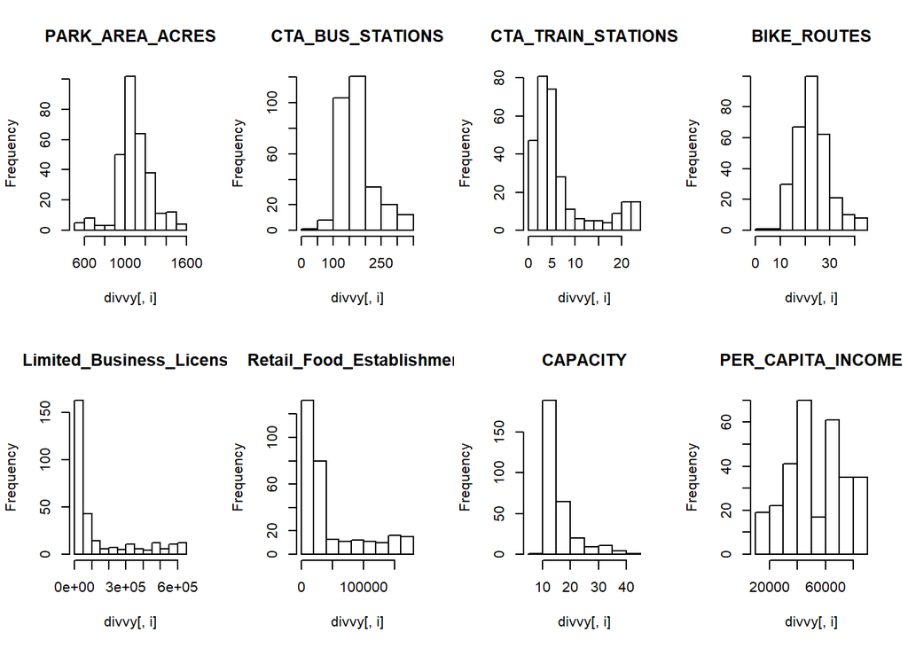

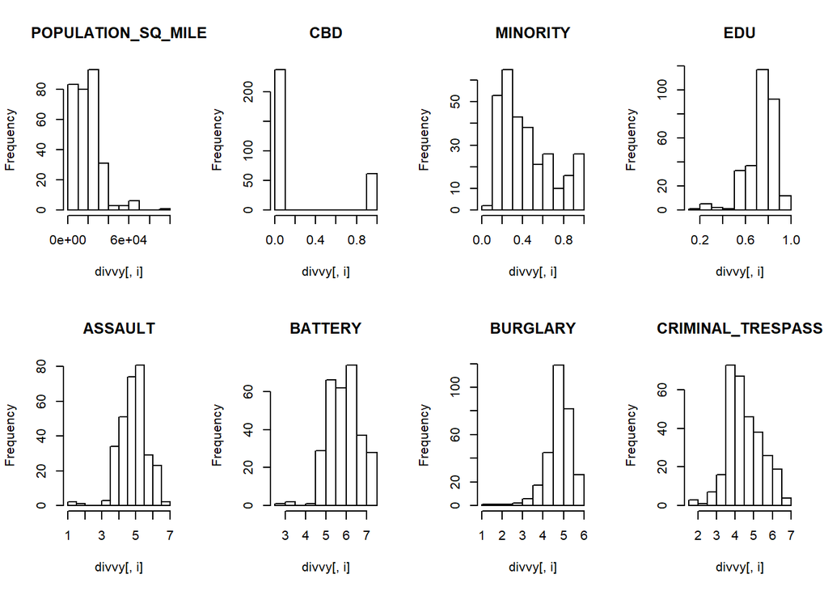

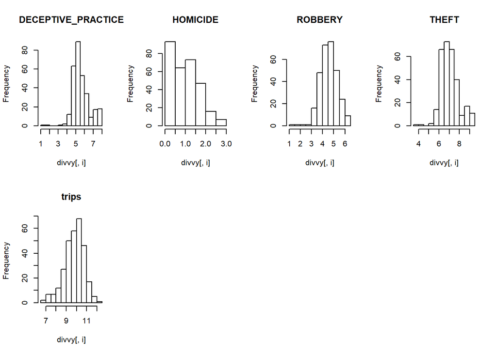

```r
divvy = divvy.full[,c(2:13,15:17,21,22,24,40,43,45)]

par(mfrow=c(2,4))
numCols = ncol(divvy)
for(i in 1:numCols){
  hist(divvy[,i], main=names(divvy)[i])
}
```

```r
summary(divvy)
```

```
##  PARK_AREA_ACRES  CTA_BUS_STATIONS CTA_TRAIN_STATIONS  BIKE_ROUTES
##  Min.   : 518.1   Min.   : 10.0    Min.   : 0.000     Min.   : 4.62
##  1st Qu.:1004.8   1st Qu.:138.0    1st Qu.: 3.000     1st Qu.:18.87
##  Median :1080.6   Median :159.0    Median : 5.000     Median :22.62
##  Mean   :1093.0   Mean   :172.4    Mean   : 7.273     Mean   :23.10
##  3rd Qu.:1190.5   3rd Qu.:193.2    3rd Qu.: 8.000     3rd Qu.:26.50
##  Max.   :1575.3   Max.   :335.0    Max.   :24.000     Max.   :43.69
##  Limited_Business_License Retail_Food_Establishment    CAPACITY
##  Min.   :  4097           Min.   :  2167            Min.   : 9.00
##  1st Qu.: 27048           1st Qu.: 14855            1st Qu.:15.00
##  Median : 44613           Median : 23294            Median :15.00
##  Mean   :144013           Mean   : 45974            Mean   :17.36
##  3rd Qu.:191933           3rd Qu.: 58489            3rd Qu.:19.00
##  Max.   :645975           Max.   :174092            Max.   :43.00
##  PER_CAPITA_INCOME POPULATION_SQ_MILE      CBD            MINORITY
##  Min.   :10402     Min.   : 1626      Min.   :0.0000   Min.   :0.0754
##  1st Qu.:37524     1st Qu.: 9506      1st Qu.:0.0000   1st Qu.:0.2334
##  Median :44689     Median :18976      Median :0.0000   Median :0.3923
##  Mean   :52534     Mean   :19417      Mean   :0.2067   Mean   :0.4404
##  3rd Qu.:65526     3rd Qu.:25297      3rd Qu.:0.0000   3rd Qu.:0.6120
##  Max.   :88669     Max.   :92179      Max.   :1.0000   Max.   :1.0000
##       EDU            ASSAULT         BATTERY         BURGLARY
##  Min.   :0.1641   Min.   :1.099   Min.   :2.890   Min.   :1.099
##  1st Qu.:0.6885   1st Qu.:4.301   1st Qu.:5.364   1st Qu.:4.522
##  Median :0.7590   Median :4.934   Median :5.947   Median :4.828
##  Mean   :0.7412   Mean   :4.861   Mean   :5.902   Mean   :4.766
##  3rd Qu.:0.8202   3rd Qu.:5.358   3rd Qu.:6.402   3rd Qu.:5.178
##  Max.   :0.9914   Max.   :6.547   Max.   :7.459   Max.   :5.953
##  CRIMINAL_TRESPASS DECEPTIVE_PRACTICE    HOMICIDE         ROBBERY
##  Min.   :1.609     Min.   :1.386      Min.   :0.0000   Min.   :1.099
##  1st Qu.:3.855     1st Qu.:4.984      1st Qu.:0.0000   1st Qu.:4.043
##  Median :4.394     Median :5.352      Median :0.6931   Median :4.570
##  Mean   :4.507     Mean   :5.564      Mean   :0.9010   Mean   :4.568
##  3rd Qu.:5.159     3rd Qu.:6.011      3rd Qu.:1.3863   3rd Qu.:5.078
##  Max.   :6.554     Max.   :7.920      Max.   :2.9957   Max.   :6.271
##      THEFT           trips
##  Min.   :3.738   Min.   : 6.743
##  1st Qu.:6.457   1st Qu.: 9.287
##  Median :6.950   Median : 9.874
##  Mean   :7.045   Mean   : 9.794
##  3rd Qu.:7.524   3rd Qu.:10.448
##  Max.   :9.244   Max.   :12.158
```

```r
round(cor(divvy), 2)
```

```
##                           PARK_AREA_ACRES CTA_BUS_STATIONS
## PARK_AREA_ACRES                      1.00            -0.14
## CTA_BUS_STATIONS                    -0.14             1.00
## CTA_TRAIN_STATIONS                  -0.06             0.76
## BIKE_ROUTES                          0.07             0.58
## Limited_Business_License            -0.11             0.79
## Retail_Food_Establishment           -0.11             0.80
## CAPACITY                            -0.09             0.47
## PER_CAPITA_INCOME                    0.04             0.05
## POPULATION_SQ_MILE                  -0.02             0.30
## CBD                                 -0.12             0.72
## MINORITY                            -0.08            -0.18
## EDU                                  0.04             0.11
## ASSAULT                             -0.11             0.74
## BATTERY                             -0.12             0.75
## BURGLARY                             0.07             0.28
## CRIMINAL_TRESPASS                   -0.12             0.78
## DECEPTIVE_PRACTICE                  -0.03             0.84
## HOMICIDE                            -0.01             0.15
## ROBBERY                             -0.01             0.70
## THEFT                               -0.13             0.83
## trips                               -0.16             0.43
##                           CTA_TRAIN_STATIONS BIKE_ROUTES
## PARK_AREA_ACRES                        -0.06        0.07
## CTA_BUS_STATIONS                        0.76        0.58
## CTA_TRAIN_STATIONS                      1.00        0.68
## BIKE_ROUTES                             0.68        1.00
## Limited_Business_License                0.94        0.72
## Retail_Food_Establishment               0.94        0.75
## CAPACITY                                0.61        0.47
## PER_CAPITA_INCOME                       0.16        0.11
## POPULATION_SQ_MILE                      0.09        0.10
## CBD                                     0.85        0.64
## MINORITY                               -0.23       -0.26
## EDU                                     0.09        0.12
## ASSAULT                                 0.52        0.39
## BATTERY                                 0.48        0.40
## BURGLARY                                0.01        0.05
## CRIMINAL_TRESPASS                       0.67        0.53
## DECEPTIVE_PRACTICE                      0.75        0.69
```

[output cut: 121 more lines]

```
## CAPACITY                     0.27  0.48  0.59
## PER_CAPITA_INCOME            0.03  0.12  0.08
## POPULATION_SQ_MILE           0.28  0.31  0.22
## CBD                          0.45  0.70  0.53
## MINORITY                     0.00 -0.32 -0.64
## EDU                          0.06  0.22  0.36
## ASSAULT                      0.85  0.73  0.04
## BATTERY                      0.89  0.77  0.13
## BURGLARY                     0.55  0.42 -0.02
## CRIMINAL_TRESPASS            0.81  0.82  0.33
## DECEPTIVE_PRACTICE           0.78  0.95  0.53
## HOMICIDE                     0.28  0.04 -0.39
## ROBBERY                      1.00  0.81  0.18
## THEFT                        0.81  1.00  0.55
## trips                        0.18  0.55  1.00
```

## Setup Training and Test data

Decided to split up the data 60/40 to train/test respectively.

```r
set.seed(12345)
train = runif(nrow(divvy))<.6
table(train)
```

```
## train
## FALSE  TRUE
##   140   160
```

# Baseline (no model)

Variance of trips with no model as the baseline.

```r
var(divvy[!train,]$trips)
```

```
## [1] 0.8617029
```

# Stepwise

Let’s first try stepwise to see how it simplifies the model.

```r
fit = lm(trips ~., divvy[train,])
summary(fit)
```

```
##
## Call:
## lm(formula = trips ~ ., data = divvy[train, ])
##
## Residuals:
##      Min       1Q   Median       3Q      Max
## -1.68102 -0.25455  0.01291  0.31754  1.35074
##
## Coefficients:
##                             Estimate Std. Error t value Pr(>|t|)
## (Intercept)                9.968e+00  8.499e-01  11.728  < 2e-16 ***
## PARK_AREA_ACRES           -7.917e-04  2.857e-04  -2.771 0.006352 **
## CTA_BUS_STATIONS          -1.622e-03  1.813e-03  -0.894 0.372749
## CTA_TRAIN_STATIONS        -3.372e-02  2.309e-02  -1.460 0.146510
## BIKE_ROUTES                3.110e-03  1.317e-02   0.236 0.813708
## Limited_Business_License   4.360e-06  5.691e-06   0.766 0.444918
## Retail_Food_Establishment -7.400e-06  2.311e-05  -0.320 0.749279
## CAPACITY                   4.922e-02  1.052e-02   4.680 6.73e-06 ***
## PER_CAPITA_INCOME         -8.746e-08  1.944e-06  -0.045 0.964180
## POPULATION_SQ_MILE         1.318e-06  4.084e-06   0.323 0.747389
## CBD                       -3.334e-01  2.317e-01  -1.439 0.152330
## MINORITY                  -1.428e+00  2.886e-01  -4.948 2.13e-06 ***
## EDU                       -2.629e-01  3.452e-01  -0.761 0.447664
## ASSAULT                   -9.329e-01  2.658e-01  -3.510 0.000604 ***
## BATTERY                    4.288e-01  2.521e-01   1.701 0.091175 .
## BURGLARY                  -2.444e-01  1.031e-01  -2.371 0.019113 *
## CRIMINAL_TRESPASS          7.708e-02  1.299e-01   0.594 0.553779
## DECEPTIVE_PRACTICE         2.312e-01  2.030e-01   1.139 0.256745
## HOMICIDE                  -3.258e-02  8.668e-02  -0.376 0.707559
## ROBBERY                    1.075e-01  1.408e-01   0.764 0.446337
## THEFT                      2.734e-01  2.296e-01   1.191 0.235745
## ---
## Signif. codes:  0 '***' 0.001 '**' 0.01 '*' 0.05 '.' 0.1 ' ' 1
##
## Residual standard error: 0.4906 on 139 degrees of freedom
## Multiple R-squared:  0.7837, Adjusted R-squared:  0.7526
## F-statistic: 25.19 on 20 and 139 DF,  p-value: < 2.2e-16
```

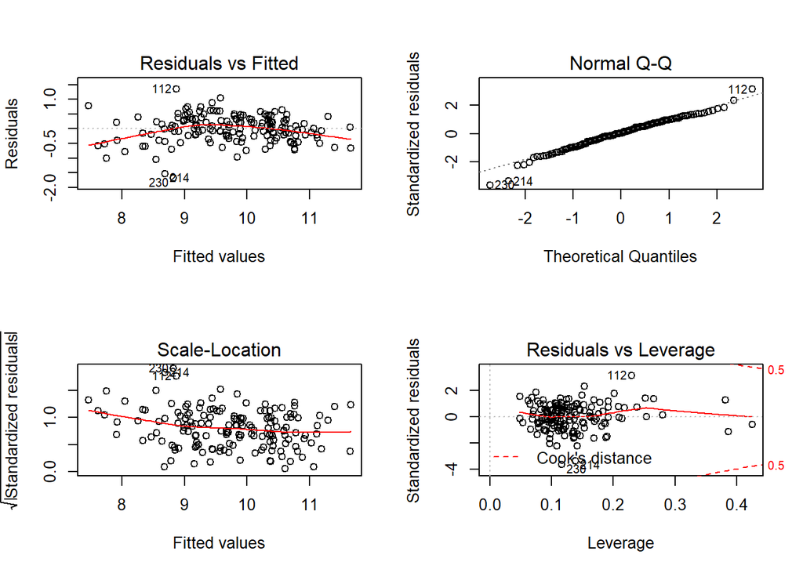

```r
par(mfrow=c(2,2))
plot(fit)
```

```r
fit.stepwise = step(fit)
```

```
## Start:  AIC=-208.36
## trips ~ PARK_AREA_ACRES + CTA_BUS_STATIONS + CTA_TRAIN_STATIONS +
##     BIKE_ROUTES + Limited_Business_License + Retail_Food_Establishment +
##     CAPACITY + PER_CAPITA_INCOME + POPULATION_SQ_MILE + CBD +
##     MINORITY + EDU + ASSAULT + BATTERY + BURGLARY + CRIMINAL_TRESPASS +
##     DECEPTIVE_PRACTICE + HOMICIDE + ROBBERY + THEFT
##
##                             Df Sum of Sq    RSS     AIC
## - PER_CAPITA_INCOME          1    0.0005 33.463 -210.36
## - BIKE_ROUTES                1    0.0134 33.476 -210.30
## - Retail_Food_Establishment  1    0.0247 33.487 -210.24
## - POPULATION_SQ_MILE         1    0.0251 33.488 -210.24
## - HOMICIDE                   1    0.0340 33.496 -210.20
## - CRIMINAL_TRESPASS          1    0.0848 33.547 -209.96
## - EDU                        1    0.1396 33.602 -209.69
## - ROBBERY                    1    0.1404 33.603 -209.69
## - Limited_Business_License   1    0.1413 33.604 -209.69
## - CTA_BUS_STATIONS           1    0.1925 33.655 -209.44
## - DECEPTIVE_PRACTICE         1    0.3122 33.775 -208.87
## - THEFT                      1    0.3414 33.804 -208.74
## <none>                                   33.462 -208.36
## - CBD                        1    0.4987 33.961 -207.99
## - CTA_TRAIN_STATIONS         1    0.5132 33.976 -207.92
## - BATTERY                    1    0.6966 34.159 -207.06
## - BURGLARY                   1    1.3533 34.816 -204.02
## - PARK_AREA_ACRES            1    1.8486 35.311 -201.76
## - ASSAULT                    1    2.9660 36.428 -196.77
## - CAPACITY                   1    5.2728 38.735 -186.95
## - MINORITY                   1    5.8944 39.357 -184.40
##
## Step:  AIC=-210.36
## trips ~ PARK_AREA_ACRES + CTA_BUS_STATIONS + CTA_TRAIN_STATIONS +
##     BIKE_ROUTES + Limited_Business_License + Retail_Food_Establishment +
##     CAPACITY + POPULATION_SQ_MILE + CBD + MINORITY + EDU + ASSAULT +
##     BATTERY + BURGLARY + CRIMINAL_TRESPASS + DECEPTIVE_PRACTICE +
##     HOMICIDE + ROBBERY + THEFT
##
##                             Df Sum of Sq    RSS     AIC
## - BIKE_ROUTES                1    0.0138 33.477 -212.29
## - Retail_Food_Establishment  1    0.0244 33.487 -212.24
```

[output cut: 223 more lines]

```
## Step:  AIC=-224.45
## trips ~ PARK_AREA_ACRES + CTA_TRAIN_STATIONS + Limited_Business_License +
##     CAPACITY + MINORITY + ASSAULT + BATTERY + BURGLARY + THEFT
##
##                            Df Sum of Sq    RSS     AIC
## <none>                                  34.721 -224.45
## - CTA_TRAIN_STATIONS        1    0.5752 35.296 -223.82
## - BATTERY                   1    0.8179 35.539 -222.73
## - Limited_Business_License  1    1.3227 36.044 -220.47
## - PARK_AREA_ACRES           1    1.4959 36.217 -219.70
## - BURGLARY                  1    1.8957 36.617 -217.95
## - ASSAULT                   1    3.6014 38.323 -210.66
## - THEFT                     1    3.8998 38.621 -209.42
## - CAPACITY                  1    5.5406 40.262 -202.76
## - MINORITY                  1    8.3218 43.043 -192.08
```

- R-squared is 0.7756 and it doesn’t seem bad looking at the plots. We have a target model.
- formula = trips ~ PARK_AREA_ACRES + CTA_TRAIN_STATIONS + Limited_Business_License + CAPACITY + MINORITY + ASSAULT + BATTERY + BURGLARY + THEFT

### After Stepwise - Summary and Plots

```r
summary(fit.stepwise)
```

```
##
## Call:
## lm(formula = trips ~ PARK_AREA_ACRES + CTA_TRAIN_STATIONS + Limited_Business_License +
##     CAPACITY + MINORITY + ASSAULT + BATTERY + BURGLARY + THEFT,
##     data = divvy[train, ])
##
## Residuals:
##      Min       1Q   Median       3Q      Max
## -1.67718 -0.27796  0.03985  0.31649  1.40456
##
## Coefficients:
##                            Estimate Std. Error t value Pr(>|t|)
## (Intercept)               9.275e+00  5.754e-01  16.120  < 2e-16 ***
## PARK_AREA_ACRES          -5.457e-04  2.146e-04  -2.542 0.012033 *
## CTA_TRAIN_STATIONS       -3.027e-02  1.920e-02  -1.576 0.117047
## Limited_Business_License  1.668e-06  6.978e-07   2.390 0.018067 *
## CAPACITY                  4.894e-02  1.000e-02   4.892 2.54e-06 ***
## MINORITY                 -1.457e+00  2.430e-01  -5.996 1.45e-08 ***
## ASSAULT                  -7.649e-01  1.939e-01  -3.944 0.000122 ***
## BATTERY                   3.652e-01  1.943e-01   1.880 0.062083 .
## BURGLARY                 -2.533e-01  8.851e-02  -2.862 0.004816 **
## THEFT                     5.155e-01  1.256e-01   4.105 6.63e-05 ***
## ---
## Signif. codes:  0 '***' 0.001 '**' 0.01 '*' 0.05 '.' 0.1 ' ' 1
##
## Residual standard error: 0.4811 on 150 degrees of freedom
## Multiple R-squared:  0.7756, Adjusted R-squared:  0.7621
## F-statistic: 57.61 on 9 and 150 DF,  p-value: < 2.2e-16
```

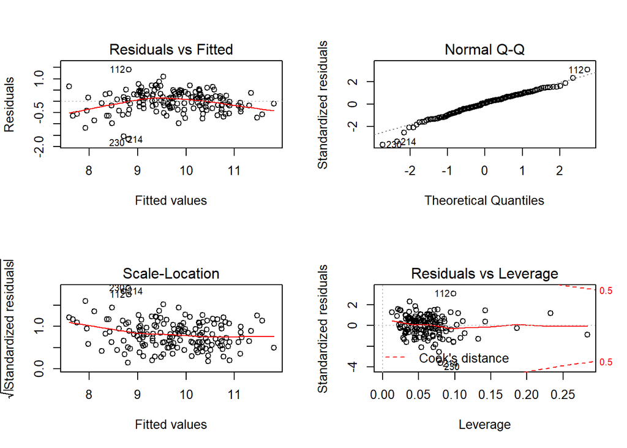

```r
par(mfrow=c(2,2))
plot(fit.stepwise)
```

### Stepwise - MSE

```r
yhat = predict(fit.stepwise, divvy[!train,])
mean((divvy[!train,]$trips-yhat)^2)
```

```
## [1] 0.2237982
```

1. PARK_AREA_ACRES: Nagative relationship with trips. Some thoughts is that if the park is small people prefer to bike, if the park is too big, people prefer to drive. Also, bikes at perimeter of parks versus being in them, so purpose and motivation to use bikes is possibly different when a park is invovled, and other activities in parks are considered versus renting and riding bikes.
2. CTA_TRAIN_STATIONS: Nagative relationship with trips. There is a possibility that if there are too many train stations, people can go to anywhere by train and therefore less need of a bike. Another thought the group had was that train stations have less correlation than buses because it is harder to make or change train stations. Busses are more flexible and their routes can even be changes. Divvy staitons are even more flexible and individual routes can vary dramatically.
3. Limited_Business_License: Positive relationship with trips. This makes sense in that more retailors means there might be more people walking and biking.
4. CAPACITY: Positive relationship with trips. Places where there are more bikes there can be more available for rental.
5. MINORITY: Nagative relationship with trips. Is is that those that are of a minority have less need for bikes or this kind of service? Thoughts that come up is possibly riding bikes is a lifestyle choice and some may already have bikes of their own so no need to rent one.
6. ASSAULT: Nagative relationship with trips. Assult by definition is the threat of harm.
7. BATTERY: Positive relationship with trips. Battery by definition is cause of real physical harm. Thought is that maybe people are more likely to walk or bike in safer area (ASSAULT) so this influences bike rental negatively. Whereas for BATTERY it is likely people will go through these areas quickly to avoid so it will influence bike rental positively.
8. BURGLARY: Nagative relationship with trips. Definition is to enter a building or residence with the intention to commit a theft or any felonious crime. This kind of crime might be more common where people live, insead of where people work or shop, so bike demand could be less.
9. THEFT: Positive relationship with trips. Definition is to take property, and it does not involve person-to-person interaction with force. It is easier to steal when people are walking or shoping than when they are driving or riding a bike.

### VIF

```r
vif(fit.stepwise)
```

```
##          PARK_AREA_ACRES       CTA_TRAIN_STATIONS Limited_Business_License
##                 1.071586                11.879628                13.120096
##                 CAPACITY                 MINORITY                  ASSAULT
##                 1.952963                 2.613368                17.118042
##                  BATTERY                 BURGLARY                    THEFT
##                16.397901                 2.592947                 9.155107
```

- CTA_TRAIN_STATIONS, Limited_Business_License, ASSAULT,BATTERY，THEFT have Multicollinearity

### K-Fold Cross Validation

K-Fold Cross Validation adding the cv column to the end of the table.

```r
set.seed(12345)
divvy.cross = divvy
divvy.cross$cv = as.integer(runif(nrow(divvy.cross))*5)
table(divvy.cross$cv)
```

```
##
##  0  1  2  3  4
## 58 55 47 69 71
```

### K-Fold MSE

Perform K-Fold Cross Validation and find the MSE of the stepwise model

```r
yhat = rep(NA, nrow(divvy.cross))

for(i in 0:4){
  fit.kfold = lm(trips ~ PARK_AREA_ACRES + CTA_TRAIN_STATIONS + Limited_Business_License + CAPACITY + MINORITY + ASSAULT + BATTERY + BURGLARY + THEFT, divvy.cross, subset=(cv!=i))
  yhat[divvy.cross$cv==i] = predict(fit.kfold, divvy.cross[divvy.cross$cv==i,])

}

mean((divvy.cross$trips-yhat)^2)
```

```
## [1] 0.2316338
```

# Ridge

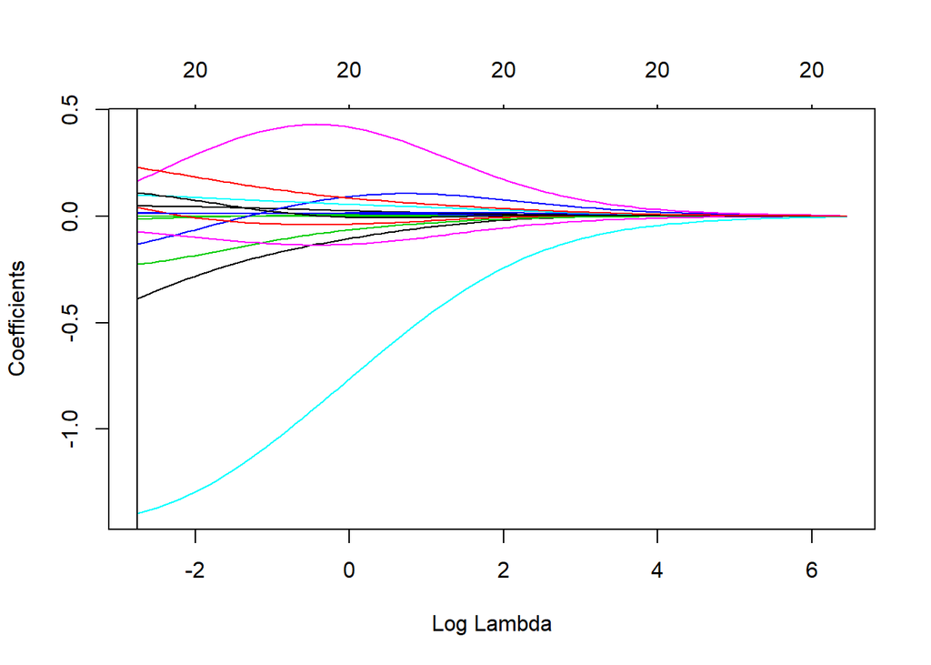

```r
x = model.matrix(divvy$trips~., divvy)
fit.ridge = glmnet(x[train,], divvy$trips[train], alpha=0)
fit.cv.ridge = cv.glmnet(x[train,], divvy$trips[train], alpha=0)
plot(fit.ridge, xvar = "lambda")
abline(v=log(fit.cv.ridge$lambda.min))
```

```r
predict(fit.ridge, x[!train,], s=fit.cv.ridge$lambda.min, type="coef")
```

```
## 22 x 1 sparse Matrix of class "dgCMatrix"
##                                       1
## (Intercept)                1.003932e+01
## (Intercept)                .
## PARK_AREA_ACRES           -7.833738e-04
## CTA_BUS_STATIONS          -3.692820e-04
## CTA_TRAIN_STATIONS        -1.294310e-02
## BIKE_ROUTES                1.145495e-02
## Limited_Business_License   5.638159e-07
## Retail_Food_Establishment  2.608624e-06
## CAPACITY                   4.781865e-02
## PER_CAPITA_INCOME         -2.310846e-07
## POPULATION_SQ_MILE         1.009746e-06
## CBD                       -1.316929e-01
## MINORITY                  -1.396033e+00
## EDU                        1.643093e-01
## ASSAULT                   -3.878097e-01
## BATTERY                    4.243634e-02
## BURGLARY                  -2.261733e-01
## CRIMINAL_TRESPASS          1.681710e-02
## DECEPTIVE_PRACTICE         9.989096e-02
## HOMICIDE                  -7.301221e-02
## ROBBERY                    1.103022e-01
## THEFT                      2.293337e-01
```

```r
yhat = predict(fit.ridge, x[!train,], s=fit.cv.ridge$lambda.min)
mean((divvy$trips[!train] - yhat)^2)
```

```
## [1] 0.2212045
```

- MSE is better than Stepwise

# Lasso

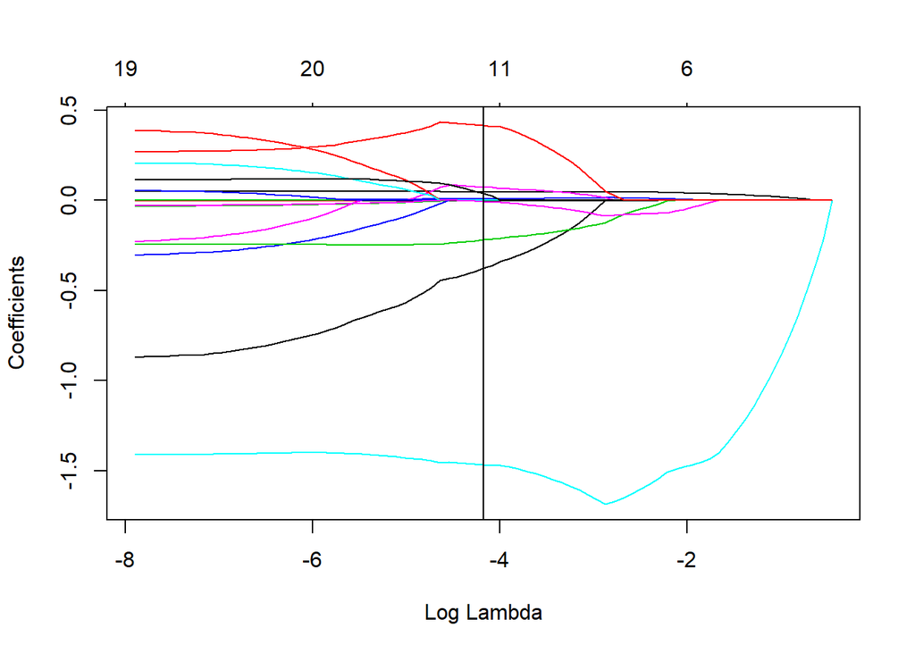

```r
x = model.matrix(divvy$trips~., divvy)
fit.lasso = glmnet(x[train,], divvy$trips[train], alpha=1)
fit.cv.lasso = cv.glmnet(x[train,], divvy$trips[train], alpha=1)
plot(fit.lasso, xvar = "lambda")
abline(v=log(fit.cv.lasso$lambda.min))
```

```r
predict(fit.lasso, x[!train,], s=fit.cv.lasso$lambda.min, type="coef")
```

```
## 22 x 1 sparse Matrix of class "dgCMatrix"
##                                       1
## (Intercept)                9.704754e+00
## (Intercept)                .
## PARK_AREA_ACRES           -6.450514e-04
## CTA_BUS_STATIONS           .
## CTA_TRAIN_STATIONS         .
## BIKE_ROUTES                9.588711e-03
## Limited_Business_License   .
## Retail_Food_Establishment  1.970461e-06
## CAPACITY                   4.819305e-02
## PER_CAPITA_INCOME          .
## POPULATION_SQ_MILE         .
## CBD                        .
## MINORITY                  -1.466097e+00
## EDU                        7.462470e-02
## ASSAULT                   -3.777598e-01
## BATTERY                    .
## BURGLARY                  -2.191356e-01
## CRIMINAL_TRESPASS          .
## DECEPTIVE_PRACTICE         .
## HOMICIDE                  -5.977620e-03
## ROBBERY                    3.824413e-02
## THEFT                      4.156402e-01
```

```r
yhat = predict(fit.lasso, x[!train,], s=fit.cv.lasso$lambda.min)
mean((divvy$trips[!train] - yhat)^2)
```

```
## [1] 0.225231
```

# Tree

[figure not shown]

```r
fit.tree = tree(trips~., divvy[train,])
plot(fit.tree, type="uniform")
text(fit.tree)
```

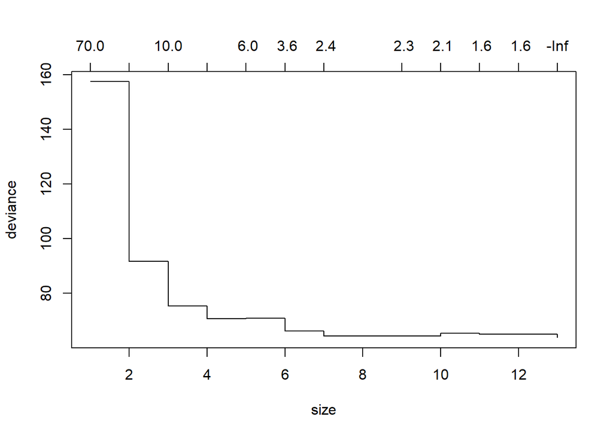

```r
plot(cv.tree(fit.tree))
```

### Prune the Tree

```r
fit.tree.prune = prune.tree(fit.tree, best=7)
fit.tree.prune
```

```
## node), split, n, deviance, yval
##       * denotes terminal node
##
##  1) root 160 154.7000  9.746
##    2) MINORITY < 0.673563 126  60.3800 10.090
##      4) Retail_Food_Establishment < 24608.5 55  20.4100  9.601
##        8) DECEPTIVE_PRACTICE < 5.15314 30  12.5000  9.368 *
##        9) DECEPTIVE_PRACTICE > 5.15314 25   4.3370  9.880 *
##      5) Retail_Food_Establishment > 24608.5 71  16.6800 10.470
##       10) CAPACITY < 21 45   6.8890 10.250 *
##       11) CAPACITY > 21 26   3.7980 10.850 *
##    3) MINORITY > 0.673563 34  24.6300  8.476
##      6) ASSAULT < 5.05623 17   5.0470  9.024 *
##      7) ASSAULT > 5.05623 17   9.3510  7.927
##       14) MINORITY < 0.881764 5   0.6055  8.859 *
##       15) MINORITY > 0.881764 12   2.5930  7.539 *
```

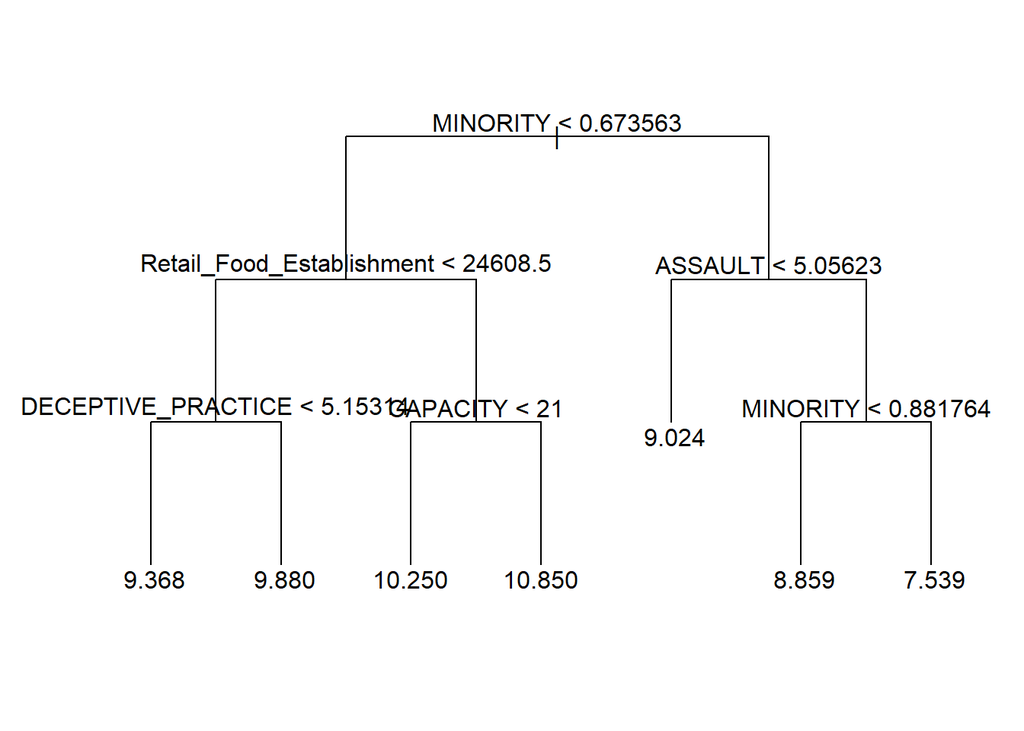

```r
plot(fit.tree.prune, type="uniform")
text(fit.tree.prune)
```

### Print MSE for tree before and after Prune

```r
yhat.tree = predict(fit.tree, divvy[!train,])
mean((divvy[!train,]$trips-yhat.tree)^2)
```

```
## [1] 0.4031656
```

```r
yhat.prune = predict(fit.tree.prune, divvy[!train,])
mean((divvy[!train,]$trips-yhat.prune)^2)
```

```
## [1] 0.3838907
```

- The MSE looks better after pruning, but it looks worse than other methods tried so far.
- It does seem that Minority seems to have a large influence on rentals, but not sure yet how crime relates.
- It seems from trees there are two types of crimes that relate, DECEPTIVE_PRACTICE and ASSAULT.

# Random Forest

```r
fit.rf = randomForest(trips~., divvy[train,], mtry=6)
fit.rf
```

```
##
## Call:
##  randomForest(formula = trips ~ ., data = divvy[train, ], mtry = 6)
##                Type of random forest: regression
##                      Number of trees: 500
## No. of variables tried at each split: 6
##
##           Mean of squared residuals: 0.2774725
##                     % Var explained: 71.31
```

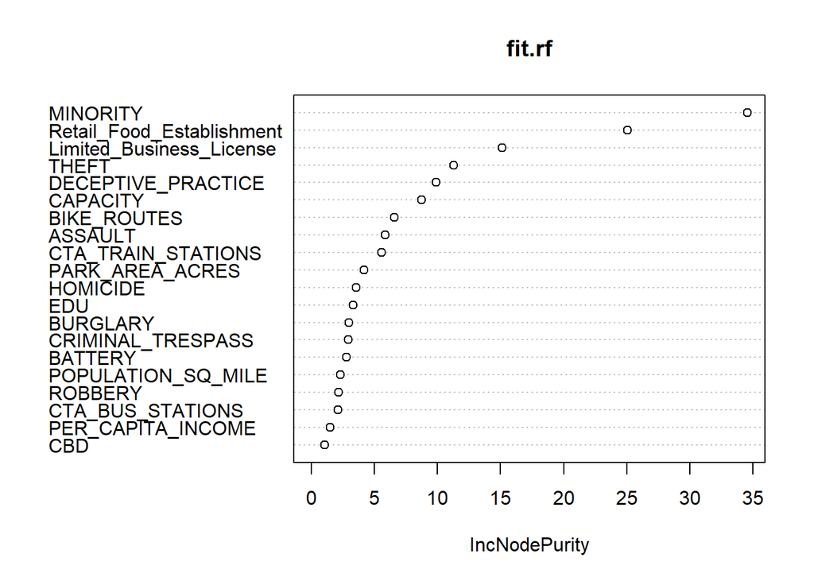

```r
varImpPlot(fit.rf)
```

- It seems to be clear that Miniority, Retail Food Establishment have great influence with bike rental.
- It seems also that deceptive practice and theft being crimes have some influence with bike rental.

### Random Forest - MSE

```r
yhat.rf = predict(fit.rf, divvy[!train,])
mean((divvy[!train,]$trips-yhat.rf)^2)
```

```
## [1] 0.2522656
```

# GBM

```r
fit.gbm = gbm(trips~., data=divvy[train,], n.trees=1000)
```

```
## Distribution not specified, assuming gaussian ...
```

```r
fit.gbm
```

```
## gbm(formula = trips ~ ., data = divvy[train, ], n.trees = 1000)
## A gradient boosted model with gaussian loss function.
## 1000 iterations were performed.
## There were 20 predictors of which 19 had non-zero influence.
```

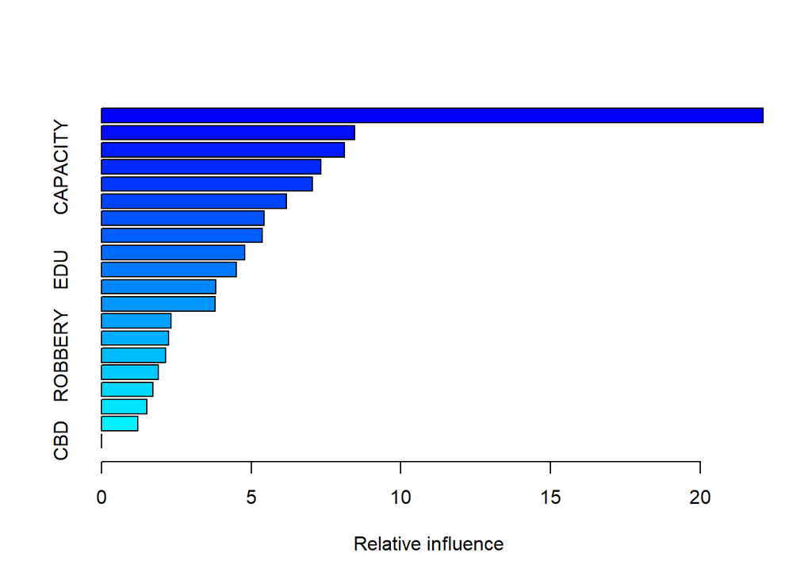

```
##                                                 var   rel.inf
## MINORITY                                   MINORITY 22.102137
## Retail_Food_Establishment Retail_Food_Establishment  8.463439
## DECEPTIVE_PRACTICE               DECEPTIVE_PRACTICE  8.115837
## CAPACITY                                   CAPACITY  7.329837
## Limited_Business_License   Limited_Business_License  7.036897
## BURGLARY                                   BURGLARY  6.180620
## BIKE_ROUTES                             BIKE_ROUTES  5.431335
## THEFT                                         THEFT  5.381466
## ASSAULT                                     ASSAULT  4.788939
## EDU                                             EDU  4.495194
## PARK_AREA_ACRES                     PARK_AREA_ACRES  3.827267
## POPULATION_SQ_MILE               POPULATION_SQ_MILE  3.791893
## BATTERY                                     BATTERY  2.327445
## HOMICIDE                                   HOMICIDE  2.251437
## ROBBERY                                     ROBBERY  2.134762
## CRIMINAL_TRESPASS                 CRIMINAL_TRESPASS  1.890371
## CTA_BUS_STATIONS                   CTA_BUS_STATIONS  1.710509
## PER_CAPITA_INCOME                 PER_CAPITA_INCOME  1.525786
## CTA_TRAIN_STATIONS               CTA_TRAIN_STATIONS  1.214829
## CBD                                             CBD  0.000000
```

```r
summary(fit.gbm)
```

### GBM - MSE

```r
yhat = predict(fit.gbm, divvy[!train,], n.trees=1000, type="response")
mean((divvy[!train,]$trips-yhat)^2)
```

```
## [1] 0.2671378
```

```r
yhat = predict(fit.gbm, divvy[!train,], n.trees=500, type="response")
mean((divvy[!train,]$trips-yhat)^2)
```

```
## [1] 0.2582442
```

```r
yhat = predict(fit.gbm, divvy[!train,], n.trees=200, type="response")
mean((divvy[!train,]$trips-yhat)^2)
```

```
## [1] 0.244593
```

```r
yhat = predict(fit.gbm, divvy[!train,], n.trees=100, type="response")
mean((divvy[!train,]$trips-yhat)^2)
```

```
## [1] 0.2479853
```

- At about 200 trees shows the lowest MSE value
- There is a difference here where along with minority and retail food establishment, capacity and theft seem to be high on the list.

# GAM

Ran a GAM to see if we have any improvement.

```r
fit.gam = gam(trips ~ s(PARK_AREA_ACRES) + s(CTA_TRAIN_STATIONS) + s(Limited_Business_License) + s(CAPACITY) + s(MINORITY) + s(ASSAULT) + s(BATTERY) + s(BURGLARY) + s(THEFT) + s(DECEPTIVE_PRACTICE), data = divvy[train,])
summary(fit.gam)
```

```
##
## Call: gam(formula = trips ~ s(PARK_AREA_ACRES) + s(CTA_TRAIN_STATIONS) +
##     s(Limited_Business_License) + s(CAPACITY) + s(MINORITY) +
##     s(ASSAULT) + s(BATTERY) + s(BURGLARY) + s(THEFT) + s(DECEPTIVE_PRACTICE),
##     data = divvy[train, ])
## Deviance Residuals:
##      Min       1Q   Median       3Q      Max
## -1.25788 -0.21652  0.01818  0.23470  1.02414
##
## (Dispersion Parameter for gaussian family taken to be 0.174)
##
##     Null Deviance: 154.7353 on 159 degrees of freedom
## Residual Deviance: 20.7087 on 118.9992 degrees of freedom
## AIC: 210.923
##
## Number of Local Scoring Iterations: 2
##
## Anova for Parametric Effects
##                              Df Sum Sq Mean Sq  F value    Pr(>F)
## s(PARK_AREA_ACRES)            1  3.446   3.446  19.8034 1.945e-05 ***
## s(CTA_TRAIN_STATIONS)         1 50.395  50.395 289.5884 < 2.2e-16 ***
## s(Limited_Business_License)   1  1.425   1.425   8.1887 0.0049813 **
## s(CAPACITY)                   1  9.367   9.367  53.8231 2.929e-11 ***
## s(MINORITY)                   1 29.261  29.261 168.1459 < 2.2e-16 ***
## s(ASSAULT)                    1  2.440   2.440  14.0206 0.0002801 ***
## s(BATTERY)                    1  3.743   3.743  21.5085 9.110e-06 ***
## s(BURGLARY)                   1  1.172   1.172   6.7352 0.0106421 *
## s(THEFT)                      1  4.804   4.804  27.6043 6.620e-07 ***
## s(DECEPTIVE_PRACTICE)         1  0.151   0.151   0.8695 0.3529731
## Residuals                   119 20.709   0.174
## ---
## Signif. codes:  0 '***' 0.001 '**' 0.01 '*' 0.05 '.' 0.1 ' ' 1
##
## Anova for Nonparametric Effects
##                             Npar Df Npar F     Pr(F)
## (Intercept)
## s(PARK_AREA_ACRES)                3 0.6901 0.5598592
## s(CTA_TRAIN_STATIONS)             3 3.4595 0.0186344 *
## s(Limited_Business_License)       3 4.4556 0.0052817 **
## s(CAPACITY)                       3 1.2285 0.3024873
## s(MINORITY)                       3 9.7792 8.126e-06 ***
## s(ASSAULT)                        3 2.0184 0.1150188
## s(BATTERY)                        3 0.7739 0.5107867
## s(BURGLARY)                       3 6.3021 0.0005269 ***
## s(THEFT)                          3 0.3932 0.7581070
## s(DECEPTIVE_PRACTICE)             3 1.7006 0.1706045
## ---
## Signif. codes:  0 '***' 0.001 '**' 0.01 '*' 0.05 '.' 0.1 ' ' 1
```

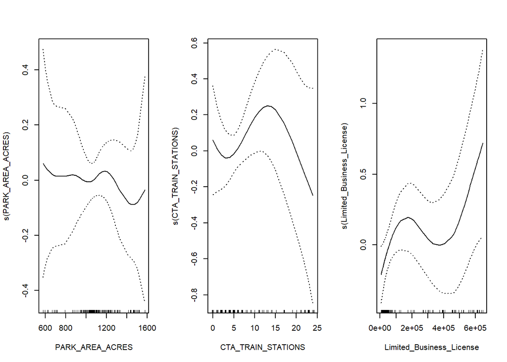

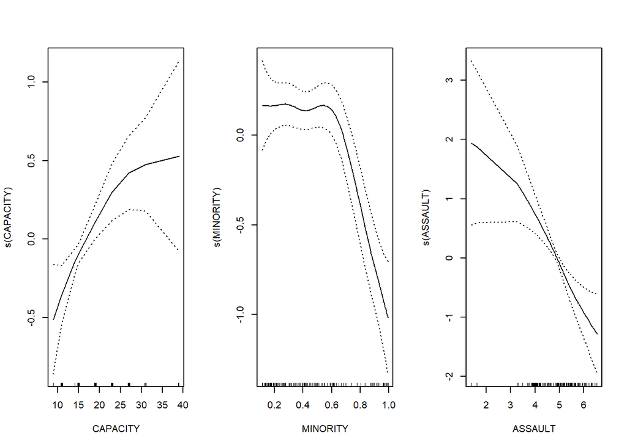

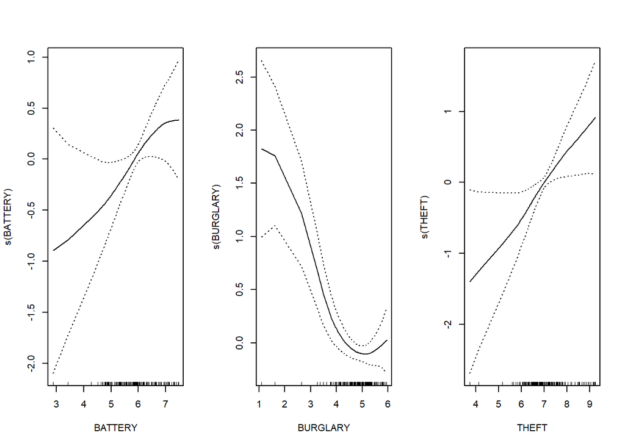

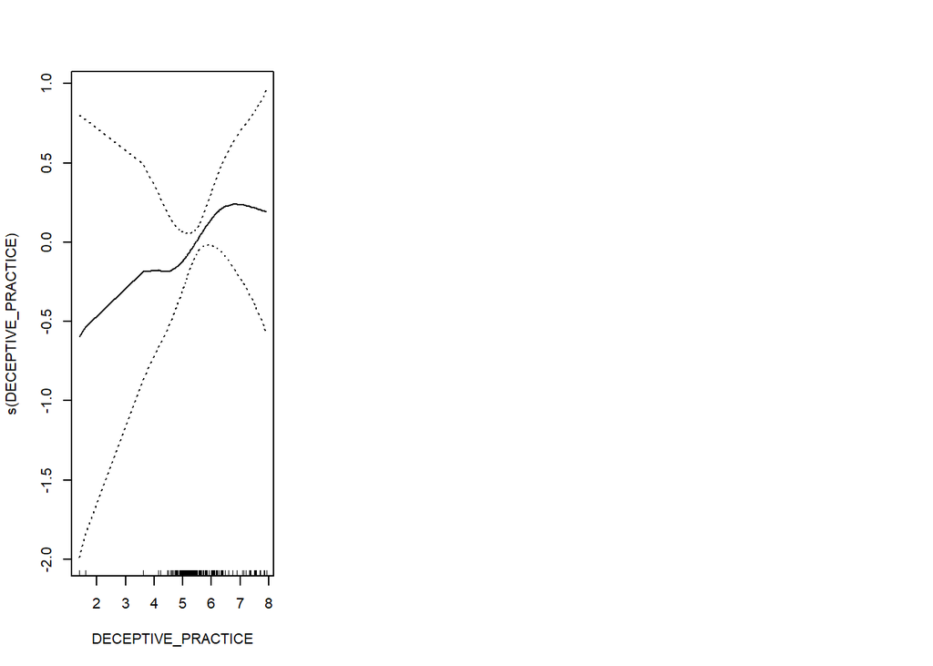

```r
par(mfrow=c(1,3))
plot(fit.gam, se=T)
```

### GAM - MSE

```r
yhat.gam = predict(fit.gam, divvy[!train,])
mean((divvy[!train,]$trips-yhat.gam)^2)
```

```
## [1] 0.2250286
```